# FigureYa3genomeView

Dekang Lv; Ying Ge, Yijing Chen

2025-5-20

### 需求描述

### requirement description

想展示我感兴趣的基因附近的ChIP-seq、DNase/ATAC-seq或RNA-seq的bigwig信号图，不想用IGV或UCSC genome browser那种截图，我想要矢量图。

I want to display bigwig signal plots of ChIP-seq, DNase/ATAC-seq, or RNA-seq near the gene I am interested in, without using screenshots from IGV or UCSC genome browser. I want vector plots.

### 使用场景

### usage scenario

场景一：用DNase/ATAC-seq或H3K4me3、H3K4me1、H3K27ac等组蛋白修饰的ChIP-seq数据证实基因启动子、增强子的位置。

场景二：展示ChIP-seq数据，证实哪些转录因子调控我的基因。

场景三：展示RNA-seq和ChIP-seq的信号，证实转录因子结合对基因转录的影响。

Scenario 1: Use DNase/ATAC-seq or ChIP-seq data of histone modifications such as H3K4me3, H3K4me1, and H3K27ac to confirm the locations of gene promoters and enhancers.

Scenario 2: Show ChIP-seq data to confirm which transcription factors regulate my genes.

Scenario 3: Show RNA-seq and ChIP-seq signals to confirm the effect of transcription factor binding on gene transcription.

### 输入数据

### Input data

需要展示的区域loci.bed

bigwig文件TAL1.bw，POLR2A.bw，文件链接： https://pan.baidu.com/s/1hUP8xf3zO2ybloflgyP73w?pwd=sp7y

bigwig文件描述easy_input.txt

Regions to be displayed loci.bed

bigwig files TAL1.bw, POLR2A.bw, file link: https://pan.baidu.com/s/1hUP8xf3zO2ybloflgyP73w?pwd=sp7y

bigwig file description easy_input.txt

### 开始画图

### Start drawing

```r
#source("http://bioconductor.org/biocLite.R")
#biocLite("Gviz","RColorBrewer")
#biocLite("TxDb.Hsapiens.UCSC.hg38.knownGene")
#biocLite("org.Hs.eg.db")
library(data.table)
library(Gviz)
library(RColorBrewer)
library(TxDb.Hsapiens.UCSC.hg38.knownGene)
txdb_hg38 <- TxDb.Hsapiens.UCSC.hg38.knownGene
grt <- GeneRegionTrack(txdb_hg38, genome="hg38",showId=TRUE, geneSymbol=TRUE, name="UCSC")
library(org.Hs.eg.db)
z <- mapIds(org.Hs.eg.db, gene(grt), "SYMBOL", "ENTREZID", multiVals = "first")
zz <- sapply(z, is.null)
z[zz] <- gene(grt)[zz]
gr <- ranges(grt)
mcols(gr)$symbol <- z
grt@range <- gr

# 输入数据
# input data
bwInfo<-read.table("easy_input.txt",header=F,row.names=1,as.is=T)
head(bwInfo)
```

```
##                                 V2
## POLR2A POLR2A_FetalLiver_GSM970259
## TAL1    TAL1_FetalLiver_GSM1427077
```

```r
gloci<-read.table("loci.bed",header=F,as.is=T)
head(gloci)
```

```
##     V1       V2       V3 V4
## 1 chr1 37996770 38005505  -
```

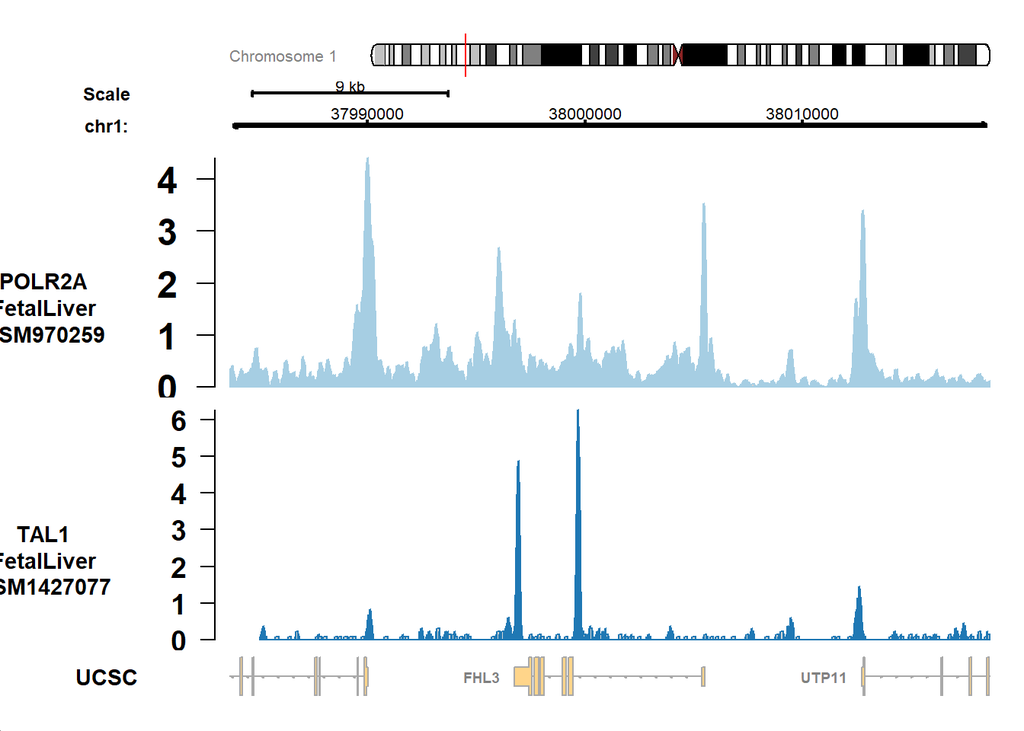

```r
#可调整的参数
#adjustable parameters
genefold<-as.numeric("1.5")#放大、缩小展示的范围 zoom in and out of the display range

# 展示的基因组范围
# range of genomes displayed
colnames(gloci)<-c("chr","start","end","strand")
chr<-gloci[rownames(gloci),]$chr
gloci$width<-with(gloci,end-start)
startpoint<-gloci[rownames(gloci),]$start-genefold*gloci[rownames(gloci),]$width
endpoint<-gloci[rownames(gloci),]$end+genefold*gloci[rownames(gloci),]$width

#下面将scale等track写入tracklist
#Write scale and other tracks into tracklist below
tracklist<-list()
#写入chromosome
#write to chromosome
itrack <- IdeogramTrack(genome = "hg38", chromosome = chr,outline=T)
tracklist[["itrack"]]<-itrack

#写入比例尺
#write to scale
scalebar <- GenomeAxisTrack(scale=0.25,col="black",fontcolor="black",name="Scale",labelPos="above",showTitle=TRUE)
tracklist[["scalebar"]]<-scalebar

#写入基因组位置
#write to genomic location
axisTrack <- GenomeAxisTrack(labelPos="above",col="black",fontcolor="black",name=paste(chr,":",sep=""),exponent=0,showTitle=TRUE)
tracklist[["axisTrack"]]<-axisTrack

#写入bigwig
#配色
#Write to bigwig
#color matching
colpal<-rep(brewer.pal(12,"Paired"),20)
coldf<-data.frame(col=colpal[1:nrow(bwInfo)],row.names = rownames(bwInfo),stringsAsFactors = F)

for(index in rownames(bwInfo)){
  bgFile<-file.path("D:/FigureYa/FigureYa3genomeView",paste(index,".bw",sep=""))
  tracklist[[index]]<-DataTrack(range = bgFile,genome="hg38",type="histogram",
                                name=chartr("_","\n",bwInfo[index,]),
                                col.histogram=coldf[index,])#每个track颜色不同才好看 each track looks better with a different color
}

#写入基因结构
#write to gene structure
tracklist[["grt"]]<-grt

#画图
#draw the plot
plotTracks(tracklist, from = startpoint, to = endpoint,
           chromosome=chr,background.panel = "white", background.title = "white",
           col.title="black",col.axis="black",
           rot.title=0,cex.title=0.9,margin=38,title.width=1.5,
           collapseTranscripts = "longest")#同一个基因的多个transcript压缩成最长的一个 multiple transcripts of the same gene compress into the longest one
```

```r
#输出pdf文件
#output pdf file
pdf("loci.pdf",height=5,width=8)
plotTracks(tracklist, from = startpoint, to = endpoint,
           chromosome=chr,background.panel = "white", background.title = "white",
           col.title="black",col.axis="black",
           rot.title=0,cex.title=0.9,margin=38,title.width=1.5,
           collapseTranscripts = "longest")#同一个基因的多个transcript压缩成最长的一个 multiple transcripts of the same gene compress into the longest one
dev.off()
```